# Dynamic_DEG_by_type_Cell

Team Le Grand

16 décembre,2021

# Found genes differentially expressed(DE) on one, or more days, for one type Cell

On one type Cell, we observe the dynamic of expression for old mice in comparison to young across days - in muscle regeneration

- For some gene, the difference between Old and Young are specific of one Day, on one step of muscle regeneration.
- For some gene, the difference is always present, no specific of one step of regeneration.
- For some gene, the age up his expression in some days and down in other day.

Here we explore this dynamic on gene DE with a good confidence (padj<=0.05) i.e. **6%** of genes ( 5902 genes on 106782). We look at DE genes by cell type, remember that some genes are DE on several cell types i.e for D0 109 genes DE on several type cell and 976 genes DE on only one typeCell (10% of gene DE sur several type cell in D0).

Overall, these are the proportions of sinificative DEG genes.

|  | ECs | FAPs | sCs | M1 | M2 | Neutro | PercentDEGSigniOnDay |
| --- | --- | --- | --- | --- | --- | --- | --- |
| D0 | 1.6 | 8.7 | 8.1 | NA | NA | NA | 18.4 |
| D2 | 1 | 4 | 32.3 | 0.5 | 1.6 | 5.3 | 44.7 |
| D4 | 4.7 | 6.6 | 23.4 | 0.3 | 0.6 | NA | 35.6 |
| D7 | 10.4 | 7 | 10.1 | NA | 2.4 | NA | 29.9 |
| PercentDEGSigniOnTyCell | 17.7 | 26.3 | 73.9 | 0.8 | 4.6 | 5.3 |  |

For all future analyses these proportions will be kept. Graphics and tables are in **/home/bioinfo/BulkAnalysis_plusNetwork2/exam_INTER_conditions/static/analysis/DynamiqueDEGbytypeCell/**

## Gene DE on only one condition

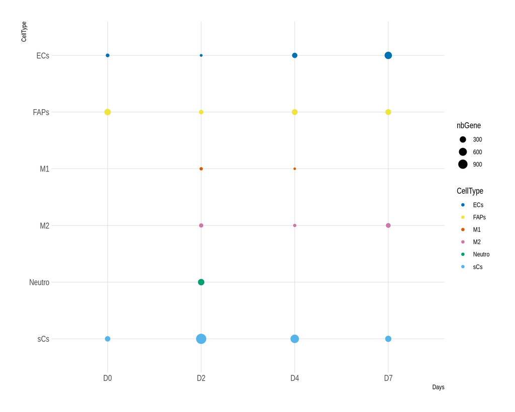

There are 76% genes DE specific on only one day.

|  | D0 | D2 | D4 | D7 |
| --- | --- | --- | --- | --- |
| Number Gene DE on Only one TypeCell | 551 | 1682 | 1147 | 1109 |
| Percent Gene DE on Only one TypeCell | 12 | 37 | 26 | 25 |

Genes differentials expressed (DE) only in **physiology state (D0)** are max in **FAPs**. For Days post injury, In the **start of the regeneration** the genes DE only in D2 are max in **sCs**. And for the **end of regeneration** in D4 and D7 the genes DE only in D4 are in **sCs** and only in D7 in **ECs**

| Type cell which the number od genes DE are maximum by Day Days | Type cell which the number od genes DE are maximum by Day CellType | Type cell which the number od genes DE are maximum by Day nbGene |
| --- | --- | --- |
| D0 | FAPs | 328 |
| D2 | sCs | 1161 |
| D4 | sCs | 706 |
| D7 | ECs | 479 |

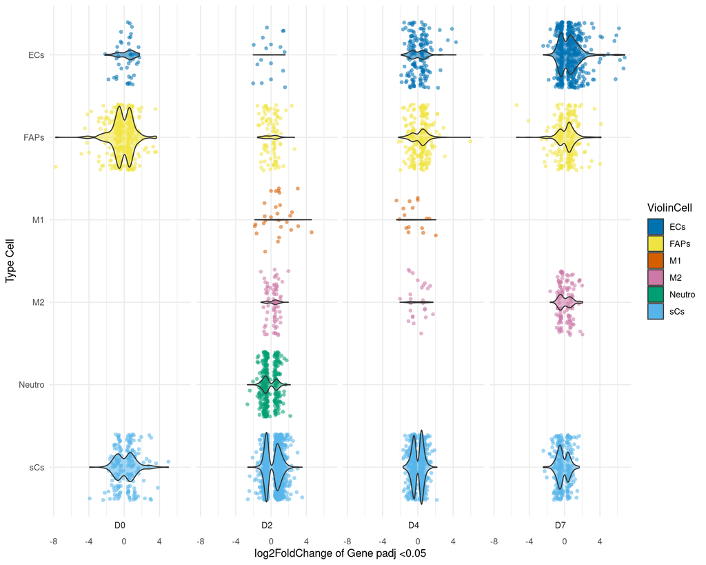

## Gene DE on more of one condition

|  | one Day | two Day | three Day | four Day |
| --- | --- | --- | --- | --- |
| Number Gene DE on | 4489 | 1170 | 208 | 35 |
| Pourcent Gene DE on | 76 | 20 | 4 | 0 |

[interactive chart not shown]

[figure not shown]

| On each combinaison Days, genes are maximum DE ECs ECs.Dynamics | On each combinaison Days, genes are maximum DE ECs ECs.number | On each combinaison Days, genes are maximum DE FAPs FAPs.Dynamics | On each combinaison Days, genes are maximum DE FAPs FAPs.number | On each combinaison Days, genes are maximum DE sCs sCs.Dynamics | On each combinaison Days, genes are maximum DE sCs sCs.number | On each combinaison Days, genes are maximum DE M2 M2.Dynamics | On each combinaison Days, genes are maximum DE M2 M2.number | On each combinaison Days, genes are maximum DE M1 M1.Dynamics | On each combinaison Days, genes are maximum DE M1 M1.number |
| --- | --- | --- | --- | --- | --- | --- | --- | --- | --- |
| D4.D7 | 73 | D0.D7 | 55 | D2.D4 | 411 | D2.D7 | 15 | D2.D4 | 3 |
| D2.D4.D7 | 11 | D2.D4.D7 | 17 | D0.D2.D4 | 38 | D2.D4.D7 | 5 | NA | NA |
| D0.D2.D4.D7 | 2 | D0.D2.D4.D7 | 24 | D0.D2.D4.D7 | 9 | NA | NA | NA | NA |

The DE genes over 2 or 3 days are predominantly expressed by the sCs. DE genes on 4 days are predominantly expressed by the FAPs

Expression of FAPs are physiologically the most impacted by age. i.e for genes DE on 2 days, it’s days 0 and 7 the most impacted For ECs the impact of age is most focused on the end of regeneration D4 et D7, the return to normal. For sCs the impact it’s focus in start of regeneration D2 and D4

Now we try to see if genes DE on more of two condition are always UP regulated with age or DOWN or if the DE dynamic change between days.

[interactive chart not shown]

[figure not shown]

We can see somes tendances, like genes D0 DOWN regulated are few UP regulated in D2, However genes D2 DOWN regulated are many to be UP regulated in D4. For more visibility, we look the tendance typeCell by typeCell

## Muscle Stem Cell - Cellule satellite sCs

[interactive chart not shown]

| nbDayDE | Dynamic | symbol | id | day | type | padj | log2FoldChange | meanCountNormalizedYoung | meanCountNormalizedOld |
| --- | --- | --- | --- | --- | --- | --- | --- | --- | --- |
| 2 | D0_DOWN.D2_DOWN | Antxr2 | ENSMUSG00000029338 | D0 | sCs | 0.00031934739057902 | -0.6349 | 1280.007 | 787.8089 |
| 2 | D0_DOWN.D2_DOWN | Antxr2 | ENSMUSG00000029338 | D2 | sCs | 0.0145876102350115 | -0.4924 | 2026.2521 | 1367.1023 |
| 2 | D0_DOWN.D2_DOWN | Bcat1 | ENSMUSG00000030268 | D0 | sCs | 0.0199491609466079 | -0.9703 | 73.6104 | 32.0486 |
| 2 | D0_DOWN.D2_DOWN | Bcat1 | ENSMUSG00000030268 | D2 | sCs | 1.21786245139114e-05 | -1.3623 | 362.217 | 131.0117 |
| 2 | D0_DOWN.D2_DOWN | Cad | ENSMUSG00000013629 | D0 | sCs | 0.0427405915685033 | -0.5341 | 433.399 | 268.2709 |
| 2 | D0_DOWN.D2_DOWN | Cad | ENSMUSG00000013629 | D2 | sCs | 0.0227977198321971 | -0.4811 | 2279.0519 | 1534.7183 |
| 2 | D0_DOWN.D2_DOWN | Dctd | ENSMUSG00000031562 | D0 | sCs | 0.000353598878093098 | -2.1154 | 63.7246 | 12.4934 |
| 2 | D0_DOWN.D2_DOWN | Dctd | ENSMUSG00000031562 | D2 | sCs | 0.00255416706386532 | -0.8779 | 409.1608 | 203.4512 |
| 2 | D0_DOWN.D2_DOWN | Ivns1abp | ENSMUSG00000023150 | D0 | sCs | 0.0340022205023123 | -0.4237 | 1686.021 | 1168.9649 |
| 2 | D0_DOWN.D2_DOWN | Ivns1abp | ENSMUSG00000023150 | D2 | sCs | 0.00054955330942288 | -0.6602 | 4651.6253 | 2818.9415 |

[output cut: 2019 more lines]

## Endothelial Cell - ECs

[interactive chart not shown]

| nbDayDE | Dynamic | symbol | id | day | type | padj | log2FoldChange | meanCountNormalizedYoung | meanCountNormalizedOld |
| --- | --- | --- | --- | --- | --- | --- | --- | --- | --- |
| 2 | D0_DOWN.D4_DOWN | Ehd4 | ENSMUSG00000027293 | D0 | ECs | 0.0161643322688469 | -0.4529 | 875.827 | 604.9455 |
| 2 | D0_DOWN.D4_DOWN | Ehd4 | ENSMUSG00000027293 | D4 | ECs | 0.0224505652011842 | -0.349 | 2802.0709 | 2108.1948 |
| 2 | D0_DOWN.D4_UP | Epb41 | ENSMUSG00000028906 | D0 | ECs | 0.0207378738732089 | -0.3378 | 5036.1696 | 3816.9303 |
| 2 | D0_DOWN.D4_UP | Epb41 | ENSMUSG00000028906 | D4 | ECs | 0.0429558616122995 | 0.3583 | 914.9761 | 1238.0066 |
| 2 | D0_DOWN.D4_UP | Lpl | ENSMUSG00000015568 | D0 | ECs | 0.00983173740633752 | -0.4527 | 14195.5429 | 9874.4155 |
| 2 | D0_DOWN.D4_UP | Lpl | ENSMUSG00000015568 | D4 | ECs | 0.0173997880103111 | 1.0823 | 1072.8097 | 2655.6378 |
| 2 | D0_DOWN.D7_DOWN | Aplnr | ENSMUSG00000044338 | D0 | ECs | 2.5301207336079e-05 | -0.6662 | 2765.8467 | 1683.0763 |
| 2 | D0_DOWN.D7_DOWN | Aplnr | ENSMUSG00000044338 | D7 | ECs | 5.63776908819392e-29 | -1.002 | 10607.9416 | 5243.2905 |
| 2 | D0_DOWN.D7_DOWN | Cd34 | ENSMUSG00000016494 | D0 | ECs | 4.197573094619e-06 | -0.5203 | 4917.3245 | 3347.8105 |
| 2 | D0_DOWN.D7_DOWN | Cd34 | ENSMUSG00000016494 | D7 | ECs | 0.000533843665428483 | -0.3495 | 9958.1619 | 7647.3461 |

[output cut: 329 more lines]

## FibroAdipogenic Progenitors - FAPs

[interactive chart not shown]

| nbDayDE | Dynamic | symbol | id | day | type | padj | log2FoldChange | meanCountNormalizedYoung | meanCountNormalizedOld |
| --- | --- | --- | --- | --- | --- | --- | --- | --- | --- |
| 2 | D0_DOWN.D2_DOWN | Col14a1 | ENSMUSG00000022371 | D0 | FAPs | 7.29168819879533e-21 | -1.1227 | 8864.7455 | 4009.7181 |
| 2 | D0_DOWN.D2_DOWN | Col14a1 | ENSMUSG00000022371 | D2 | FAPs | 2.08222635725345e-09 | -0.8157 | 5112.3221 | 2833.6983 |
| 2 | D0_DOWN.D2_DOWN | Depdc1a | ENSMUSG00000028175 | D0 | FAPs | 0.0134949605268543 | -0.0594 | 16.8172 | 0.5205 |
| 2 | D0_DOWN.D2_DOWN | Depdc1a | ENSMUSG00000028175 | D2 | FAPs | 0.0121675987372902 | -0.759 | 262.4512 | 140.2251 |
| 2 | D0_DOWN.D2_DOWN | Efna5 | ENSMUSG00000048915 | D0 | FAPs | 0.0354523175737297 | -0.7595 | 120.4053 | 61.2109 |
| 2 | D0_DOWN.D2_DOWN | Efna5 | ENSMUSG00000048915 | D2 | FAPs | 0.038811801258167 | -1.0468 | 112.779 | 45.2311 |
| 2 | D0_DOWN.D2_DOWN | H1f3 | ENSMUSG00000052565 | D0 | FAPs | 0.00360656465032066 | -1.2056 | 135.0519 | 50.7979 |
| 2 | D0_DOWN.D2_DOWN | H1f3 | ENSMUSG00000052565 | D2 | FAPs | 1.60032592367967e-12 | -1.4842 | 783.7825 | 271.221 |
| 2 | D0_DOWN.D2_DOWN | H1f5 | ENSMUSG00000058773 | D0 | FAPs | 1.77997988422242e-05 | -4.8014 | 40.1633 | 1.041 |
| 2 | D0_DOWN.D2_DOWN | H1f5 | ENSMUSG00000058773 | D2 | FAPs | 5.83486420894615e-12 | -1.4178 | 1047.439 | 379.4438 |

[output cut: 663 more lines]

## Macrophage 2 - M2

[interactive chart not shown]

| nbDayDE | Dynamic | symbol | id | day | type | padj | log2FoldChange | meanCountNormalizedYoung | meanCountNormalizedOld |
| --- | --- | --- | --- | --- | --- | --- | --- | --- | --- |
| 2 | D2_DOWN.D4_DOWN | Plxna2 | ENSMUSG00000026640 | D2 | M2 | 6.90100640748047e-06 | -1.9843 | 115.5304 | 26.523 |
| 2 | D2_DOWN.D4_DOWN | Plxna2 | ENSMUSG00000026640 | D4 | M2 | 6.85972650048823e-05 | -1.2278 | 277.3767 | 111.4984 |
| 2 | D2_DOWN.D7_DOWN | Ankrd28 | ENSMUSG00000014496 | D2 | M2 | 0.00557302242164133 | -0.4302 | 2926.9222 | 2083.4877 |
| 2 | D2_DOWN.D7_DOWN | Ankrd28 | ENSMUSG00000014496 | D7 | M2 | 0.0214993328213926 | -0.4587 | 869.8244 | 593.8584 |
| 2 | D2_DOWN.D7_DOWN | Cgnl1 | ENSMUSG00000032232 | D2 | M2 | 0.0305096318022 | -0.4728 | 736.2775 | 496.0675 |
| 2 | D2_DOWN.D7_DOWN | Cgnl1 | ENSMUSG00000032232 | D7 | M2 | 0.0192390806100888 | -0.0314 | 72.0461 | 21.2567 |
| 2 | D2_DOWN.D7_DOWN | Fcrls | ENSMUSG00000015852 | D2 | M2 | 1.8202963985887e-11 | -0.9616 | 1876.5168 | 940.4506 |
| 2 | D2_DOWN.D7_DOWN | Fcrls | ENSMUSG00000015852 | D7 | M2 | 0.00021670628417705 | -0.4909 | 3363.0447 | 2317.4383 |
| 2 | D2_DOWN.D7_DOWN | Itga9 | ENSMUSG00000039115 | D2 | M2 | 0.000431747441215482 | -0.7768 | 344.2492 | 190.3945 |
| 2 | D2_DOWN.D7_DOWN | Itga9 | ENSMUSG00000039115 | D7 | M2 | 0.00664716839026382 | -0.37 | 2345.4814 | 1748.3159 |

[output cut: 47 more lines]

## Macrophage 1 - M1

[interactive chart not shown]

| nbDayDE | Dynamic | symbol | id | day | type | padj | log2FoldChange | meanCountNormalizedYoung | meanCountNormalizedOld |
| --- | --- | --- | --- | --- | --- | --- | --- | --- | --- |
| 2 | D2_DOWN.D4_DOWN | Plxna2 | ENSMUSG00000026640 | D2 | M1 | 0.0395192497060133 | 0 | 46.8352 | 9.7014 |
| 2 | D2_DOWN.D4_DOWN | Plxna2 | ENSMUSG00000026640 | D4 | M1 | 1.12286617929682e-06 | -2.182 | 125.4956 | 25.4936 |
| 2 | D2_UP.D4_UP | A530032D15Rik | ENSMUSG00000089844 | D2 | M1 | 0.00275000165845414 | 1.2001 | 88.432 | 222.5186 |
| 2 | D2_UP.D4_UP | A530032D15Rik | ENSMUSG00000089844 | D4 | M1 | 0.00231865434982962 | 1.0873 | 137.6158 | 315.2551 |
| 2 | D2_UP.D4_UP | C4b | ENSMUSG00000073418 | D2 | M1 | 8.90563367792302e-08 | 1.9639 | 145.8828 | 604.7223 |
| 2 | D2_UP.D4_UP | C4b | ENSMUSG00000073418 | D4 | M1 | 0.0112502470567319 | 0.8397 | 520.7154 | 1004.215 |

# HEAD Table recapitulatif

| symbol | nbDayDE | Dynamic | id | day | type | padj | log2FoldChange | meanCountNormalizedYoung | meanCountNormalizedOld |
| --- | --- | --- | --- | --- | --- | --- | --- | --- | --- |
| C4b | 3 | D2_UP.D4_UP.D7_UP | ENSMUSG00000073418 | D2 | M2 | 2.26814288079248e-10 | 1.9075 | 67.5574 | 267.4453 |
| C4b | 3 | D2_UP.D4_UP.D7_UP | ENSMUSG00000073418 | D4 | M2 | 0.00032536183106648 | 0.963 | 317.4045 | 656.2569 |
| C4b | 3 | D2_UP.D4_UP.D7_UP | ENSMUSG00000073418 | D7 | M2 | 1.12878271495032e-15 | 1.3087 | 594.9828 | 1508.9978 |
| C4b | 2 | D2_UP.D4_UP | ENSMUSG00000073418 | D2 | M1 | 8.90563367792302e-08 | 1.9639 | 145.8828 | 604.7223 |
| C4b | 2 | D2_UP.D4_UP | ENSMUSG00000073418 | D4 | M1 | 0.0112502470567319 | 0.8397 | 520.7154 | 1004.215 |
| C4b | 1 | D2_UP | ENSMUSG00000073418 | D2 | Neutro | 0.00168117762706364 | 1.7635 | 42.3539 | 170.0887 |
| C4b | 1 | D2_UP | ENSMUSG00000073418 | D2 | sCs | 2.76347552724158e-05 | 1.5361 | 92.4862 | 293.1857 |
| C4b | 1 | D4_UP | ENSMUSG00000073418 | D4 | FAPs | 1.35176274617256e-09 | 0.9665 | 1399.785 | 2811.6533 |
| C4b | 1 | D7_UP | ENSMUSG00000073418 | D7 | ECs | 0.00292715052201595 | 3.2702 | 1.9394 | 26.72 |
| Lifr | 3 | D0_UP.D2_UP.D4_UP | ENSMUSG00000054263 | D0 | FAPs | 1.0064106363444e-08 | 0.6902 | 3624.7881 | 5962.5349 |

[output cut: 7583 more lines]